# 1. Data quality

You will generate some data quality insights for two models we have worked in the past:

- *DFT error estimation*

**The first model is based on a regularized Ridge algorithm and the code is given. Use the L2 model with α = 2. Also, notice that the features are already imputed with zero values when a subgroup is absent. In your analysis, you need to calculate the completeness as the percentage of non-zero elements per column.**

```python
import pandas as pd
import numpy as np
import matplotlib.pyplot as plt
import seaborn as sns
from sklearn.model_selection import train_test_split
from sklearn import linear_model
from IPython import display as show

import warnings
warnings.filterwarnings('ignore')

sns.set_theme(context='notebook', style='darkgrid', palette='brg', font='sans-serif', font_scale=1.5, color_codes=True)
```

### Import the data - Extract X and y (y: the last column of the table)

```python
# Read the Excel file given
X_y = pd.read_excel('data.xlsx', index_col=None, header=None)

# Seperatingn the Target Values
X = X_y.drop([713], axis = 1)
y = X_y[713]
```

### Explore the inputs X (1676 rows; 713 columns)

```python
# Exploring the X inputs
show.display(X)
print(X.shape)

# Exploring the y inputs
show.display(y)
print(y.shape)
```

|  | 0 | 1 | 2 | 3 | 4 | 5 | 6 | 7 | 8 | 9 | ... | 703 | 704 | 705 | 706 | 707 | 708 | 709 | 710 | 711 | 712 |
| --- | --- | --- | --- | --- | --- | --- | --- | --- | --- | --- | --- | --- | --- | --- | --- | --- | --- | --- | --- | --- | --- |
| 0 | 0 | 10 | 0 | 0 | 13 | 0 | 0 | 0 | 0 | 0 | ... | 0 | 0 | 0 | 0 | 0 | 9 | 16 | 0 | 0 | 0 |
| 1 | 2 | 2 | 0 | 3 | 0 | 0 | 0 | 1 | 1 | 0 | ... | 0 | 0 | 0 | 0 | 0 | 5 | 3 | 4 | 1 | 0 |
| 2 | 0 | 8 | 0 | 0 | 10 | 0 | 0 | 0 | 0 | 0 | ... | 0 | 0 | 0 | 0 | 0 | 8 | 15 | 0 | 1 | 0 |
| 3 | 6 | 19 | 0 | 14 | 22 | 0 | 8 | 6 | 8 | 0 | ... | 0 | 0 | 0 | 0 | 0 | 22 | 26 | 0 | 0 | 0 |
| 4 | 0 | 1 | 0 | 0 | 0 | 0 | 0 | 0 | 0 | 0 | ... | 0 | 0 | 0 | 0 | 0 | 2 | 6 | 1 | 0 | 0 |
| ... | ... | ... | ... | ... | ... | ... | ... | ... | ... | ... | ... | ... | ... | ... | ... | ... | ... | ... | ... | ... | ... |
| 1671 | 0 | 9 | 1 | 0 | 8 | 1 | 0 | 0 | 0 | 0 | ... | 0 | 0 | 0 | 0 | 0 | 10 | 19 | 0 | 1 | 0 |
| 1672 | 0 | 4 | 0 | 0 | 6 | 0 | 0 | 0 | 0 | 0 | ... | 0 | 0 | 0 | 0 | 0 | 7 | 12 | 4 | 0 | 0 |
| 1673 | 3 | 11 | 0 | 10 | 12 | 0 | 8 | 3 | 8 | 0 | ... | 0 | 0 | 0 | 0 | 0 | 13 | 18 | 0 | 0 | 0 |
| 1674 | 1 | 5 | 0 | 2 | 3 | 0 | 2 | 0 | 1 | 0 | ... | 0 | 0 | 0 | 0 | 0 | 7 | 14 | 0 | 0 | 0 |
| 1675 | 3 | 7 | 0 | 7 | 7 | 0 | 4 | 3 | 4 | 0 | ... | 0 | 0 | 0 | 0 | 0 | 10 | 14 | 1 | 0 | 0 |

1676 rows × 713 columns

```
(1676, 713)
```

```
0        55.595625
1       133.960972
2        57.694308
3       172.426580
4        22.202958
           ...
1671     74.395230
1672    104.435443
1673    100.891600
1674     44.644840
1675     95.760584
Name: 713, Length: 1676, dtype: float64
```

```
(1676,)
```

### The input is sparse. Let's plot the sparsity pattern (spy plot: blue $\neq$ 0, white = 0)

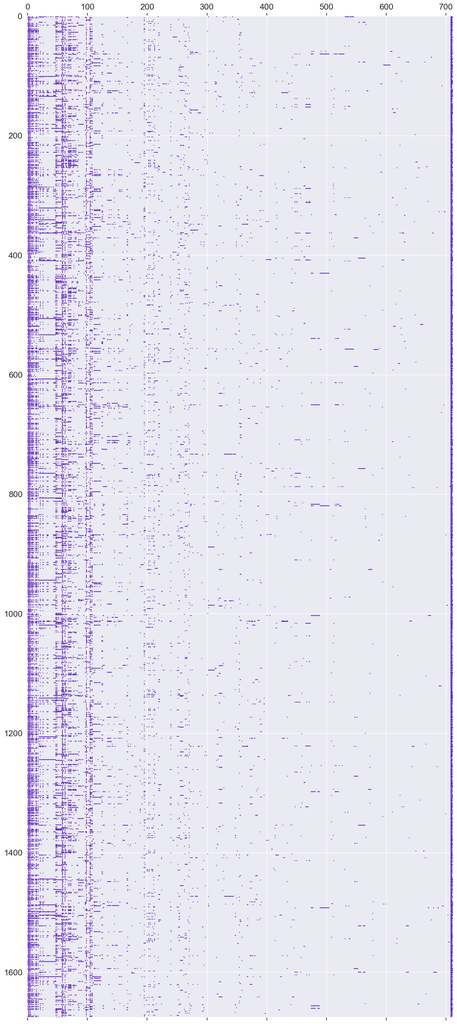

```python
plt.figure(figsize = (20, 36), dpi = 100)
plt.spy(X, precision = 0, markersize = 0.5)
plt.show()
```

### What is the percentage of non-zero elements in table X

```python
print("The percentage of non-zero elements in X is: {:.2f} %".format(np.count_nonzero(X) / X.size * 100))
```

```
The percentage of non-zero elements in X is: 2.98 %
```

### Explore the distribution of the output error we are predicting

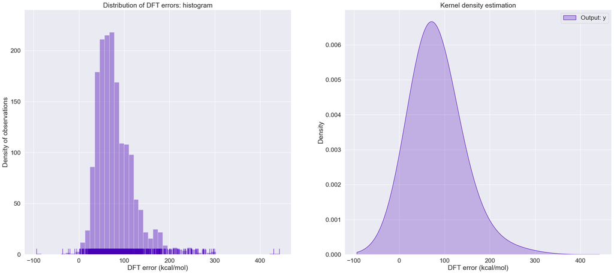

```python
f, axes = plt.subplots(1, 2, figsize = (28, 12), dpi = 100)
# Left plot: Histogram
sns.distplot(y, kde = False, norm_hist = False, rug = True, label = "Output: y", ax = axes[0])
axes[0].set_title('Distribution of DFT errors: histogram')
axes[0].set_xlabel('DFT error (kcal/mol)')
axes[0].set_ylabel('Count of observations')

# Right plot: Kernel Density Estimation
sns.kdeplot(y, shade = True, clip = (y.min(),y.max()), bw_method = 1, label = "Output: y", ax = axes[1])
axes[1].set_title('Kernel density estimation')
axes[1].set_xlabel('DFT error (kcal/mol)')
axes[0].set_ylabel('Density of observations')
plt.legend()
plt.show()
```

### Split X and y in training and test sets

```python
X_train, X_test, y_train, y_test = train_test_split(X, y, test_size = 0.5, random_state = 1)
print('X_train shape =', X_train.shape)
print('y_train shape =', y_train.shape)
print('X_test shape =', X_test.shape)
print('y_test shape =', y_test.shape)
```

```
X_train shape = (838, 713)
y_train shape = (838,)
X_test shape = (838, 713)
y_test shape = (838,)
```

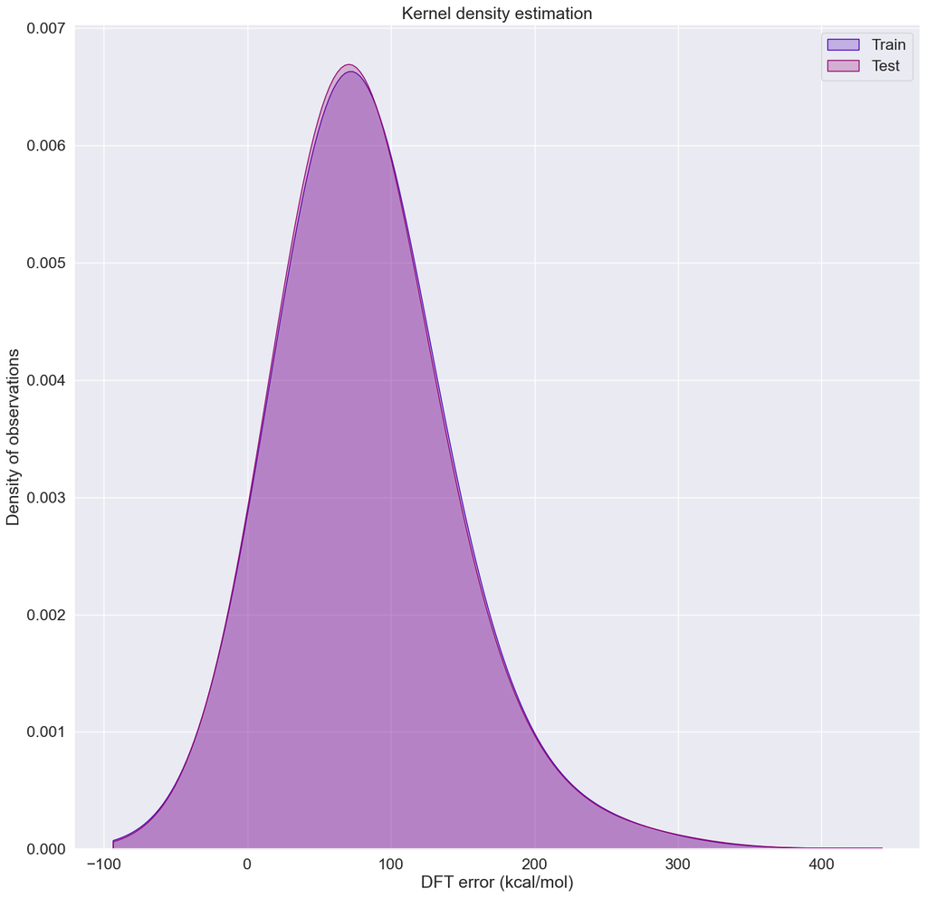

```python
f, axes = plt.subplots(1, 1, figsize = (16, 16), dpi = 100)
# Train and Test: Kernel Density Estimation
sns.kdeplot(y_train, shade = True, clip = (y.min(),y.max()), bw_method = 1, label = "Train")
sns.kdeplot(y_test, shade = True, clip = (y.min(),y.max()), bw_method = 1, label = "Test")
axes.set_title('Kernel density estimation')
axes.set_xlabel('DFT error (kcal/mol)')
axes.set_ylabel('Density of observations')
plt.legend()
plt.show()
```

### Create a Ridge regression model ($L_2$ regularization)

```python
# Smaller values, stronger regularization, more coefficients will go to zero
# You can also use: alphas = np.logspace(-2,0,10) to generate 10 logarithmically spaced points between 10^-2 and 10^0.

# Initiate the Ridge Model (L2 Logistic Regression Model)
Model_L2 = linear_model.Ridge(alpha=2)

# Fit the model
Model_L2.fit(X_train, y_train)
Train_Error_L2 = np.mean(abs(Model_L2.predict(X_train) - y_train))
Test_Error_L2  = np.mean(abs(Model_L2.predict(X_test) - y_test))
Model_Coeff_L2 = Model_L2.coef_
NonZeroCoeff_L2 = X.shape[1] - (Model_L2.coef_ == 0).sum()

print('Train error for Ridge Regression Model =', Train_Error_L2)
print('\nTest error for Ridge Regression Model =', Test_Error_L2)
print('\nRidge Regression Model Coefficients: \n', Model_Coeff_L2)
print('\nRidge Regression Model Non-0 Coefficients =', NonZeroCoeff_L2)
```

[output not shown]

[output cut: 131 more lines]

```
 -2.33451038e-02 -3.71461010e-01  1.75161017e+00 -1.33340696e+00
 -1.33340696e+00  0.00000000e+00  0.00000000e+00  0.00000000e+00
  0.00000000e+00  0.00000000e+00  0.00000000e+00 -3.18961765e+00
 -2.93902262e-01  0.00000000e+00  0.00000000e+00  3.33897297e-01
  3.33897297e-01  3.33897297e-01  3.33897297e-01  3.33897297e-01
  1.66948648e-01  0.00000000e+00  0.00000000e+00  0.00000000e+00
 -1.12013624e+00 -2.58775638e+00 -2.58775638e+00 -1.29387819e+00
  0.00000000e+00  1.13725055e-01 -2.98383629e-01 -2.98383629e-01
  0.00000000e+00  1.73741951e-01  1.73741951e-01  0.00000000e+00
  0.00000000e+00  0.00000000e+00  0.00000000e+00 -1.65915857e-01
  0.00000000e+00  0.00000000e+00 -2.61783083e-01 -2.61783083e-01
  3.24606906e+01 -1.18785279e+01  1.94873601e+01  1.96805115e+00
 -1.02047615e-01]

Ridge Regression Model Non-0 Coefficients = 620
```

### Compute Completeness

```python
completeness = []
for i in range(713):
    temp = np.count_nonzero(X_train.iloc[:,i] / len(X_train.iloc[:,i]) * 100)
    completeness.append(temp)

# show.display(completeness)
```

### Figure - Feature Importance v/s Completeness

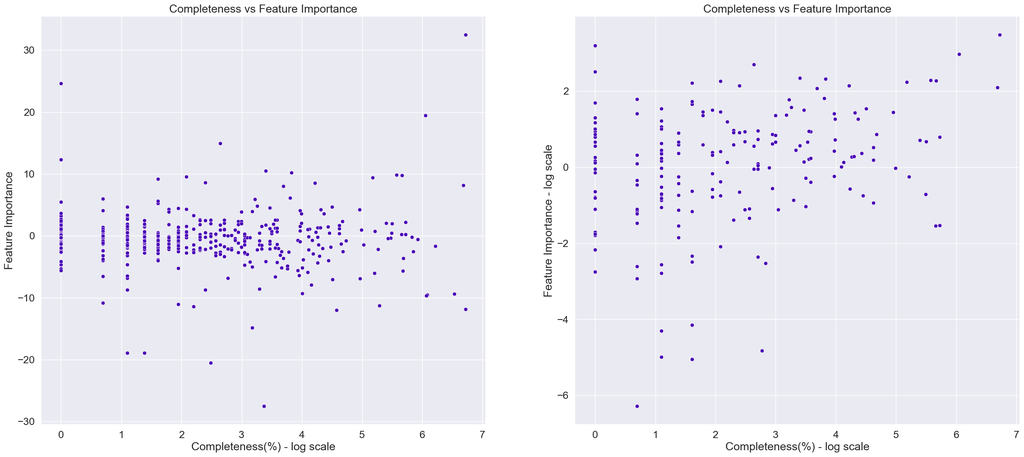

```python
log_completeness = np.log(completeness)
log_feature_imp = np.log(Model_Coeff_L2)

f, axes = plt.subplots(1,2, figsize = (28,12), dpi = 100)

sns.scatterplot(log_completeness, Model_Coeff_L2, ax = axes[0])
axes[0].set_xlabel('Completeness(%) - log scale')
axes[0].set_ylabel('Feature Importance')
axes[0].set_title('Completeness vs Feature Importance')

sns.scatterplot(log_completeness, log_feature_imp, ax = axes[1])
axes[1].set_xlabel('Completeness(%) - log scale')
axes[1].set_ylabel('Feature Importance - log scale')
axes[1].set_title('Completeness vs Feature Importance')
plt.show()
```

### Comment

Therefore I would `recommend and porbably implement the redesigning of the dataset with more complete features` as more completeness of features would generally have higher feature importance and would have a greater accuracy overall.